# Profile Likelihood Estimation of the Correlation Coefficient in the Presence of Left, Right or Interval Censoring and Missing Data

# Simulation studies

Extensive simulations have been done to demonstrate different aspects of the performance of *clikcorr* under various settings of sample size, percent censoring, and underlying distribution. We show these results in the following subsections.

## Coverage probability of the confidence interval

First, we investigate the coverage probability of the confidence intervals with two types of right censoring, termed “fixed point” and “random”, as described further below. Data were generated from the bivariate normal distribution, and inference assumed the same distribution.

In the fixed point right censoring setting, all observations were censored at the same value. Different fixed points were calculated to give expected censoring rates of $0\%$, $25\%$ and $75\%$. For the random right censoring setting, values were censored at randomly generated thresholds, which were generated from normal distributions with means set at different values to produce data with specific expected censoring proportions. Tables 4 and 5 give the simulated coverage probabilities for different settings of sample sizes and censoring rates. In the completely observed cases in Table 4, coverage probabilities calculated using the Fisher transformation rather than the profile likelihood approach are given in parentheses for comparison.

It can be seen from Tables 4 and 5 that *clikcorr* gives satisfying confidence interval coverage probabilities in both the fixed and random censoring settings. In the completely observed cases, coverage probabilities for both profile likelihood and Fisher transformation based confidence intervals are very close to the nominal level of $0.95$

## Run time, bias and mean squared error (MSE)

Table 6 shows the run time of *clikcorr* under different settings of sample sizes and censoring proportion configurations, using the bivariate normal distribution for both data generation and inference. The censoring proportion configurations, for example “$X 15\%, XY 15\%, Y 15\%$" means that $15\%$ of the observations are censored only for $X$, $15\%$ are censored for both $X$ and $Y$, and $15\%$ are censored only for $Y$. It can be seen that longer run time is needed for larger sample size, larger proportion with both $X$ and $Y$ being censored, or larger magnitude of the correlation. A typical run time ranges from a few seconds to a few minutes.

Table 7 shows the estimates of the bias and MSE for inference on $\rho$ using the bivariate normal distribution for data generation and inference, and with random right censoring. Essentially, *clikcorr* provides an unbiased estimator of the correlation coefficient.

## Gaussian versus Student t models

The coverage probabilities within the parentheses in Table 8 are for confidence intervals constructed using the bivariate $t$ distributions. Compared to inference based on the bivariate normal distribution, using the bivariate $t$ distribution provides much better coverage probabilities in settings with very heavy-tailed distributions and high correlations.

The *clikcorr* package does not provide a way to test whether the data are drawn from a heavy tailed distribution or not, nor does it estimate the best value of d.f. to use. The users could refer to Bryson (1974; Resnick 2007) or use QQ plots to guide their decision on which model to use.

# Dioxin exposure datasets

In this section, we used *clikcorr* to analyze two real world datasets and compared the results to conventional approaches.

## Owl feather data

The first dataset was analyzed in (Jaspers et al. 2013) which used an early version of *clikcorr* to estimate correlations for left-censored (below detection) data. The data contain Perfluorooctane sulfonate (PFOS) substances in feathers and soft tissues (liver, muscle, adipose tissue and preen glands) of barn owl road-kill victims collected in the province of Antwerp, Belgium. Figure 3 gives an example scatter plot (upper panel) and an example plot of the profile log likelihood of the correlation between PFOS in liver tissue and feathers using *clikcorr*. Figure 4 shows the scatter plot matrix across tail feather and the tissues generated by *clikcorr*. The asymmetrical shape of the profile likelihood reflects the asymmetrical sampling distribution, and leads to a confidence interval that is longer to the left than to the right of the point estimate.

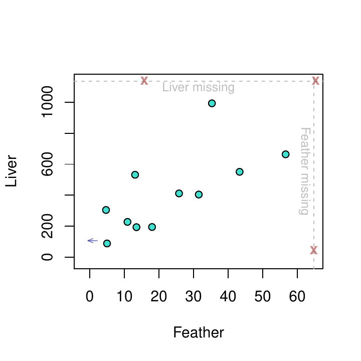

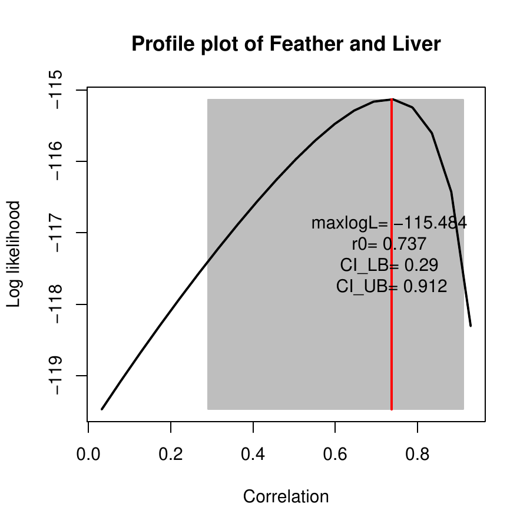

Figure 3: Output graphics from analyzing the owl feather data using *clikcorr*. Upper panel: scatter plot of PFOS in liver tissue vs. feathers; Lower panel: profile log likelihood plot for the correlation coefficient between PFOS concentration in liver and in feathers.

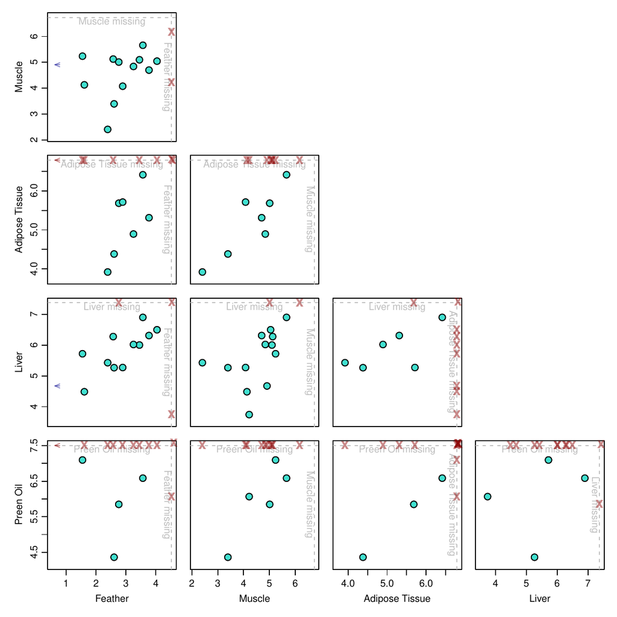

Figure 4: Scatter plot matrix from analyzing the owl feather data using *clikcorr*.

## NHANES data

In the second analysis using *clikcorr*, we analyzed dioxin data from the 2002-2003 National Health and Nutrition Examination Survey (NHANES). NHANES is one of the most widely-used datasets describing the health and nutritional status of people residing in the US. The data we analyzed contained $22$ chemicals, including $7$ dioxins, $9$ furans and $6$ polychlorinated biphenyls (PCBs) across $1643$ individuals. Correlations between these chemicals are common, and are of interest for several reasons. First, dioxins with high correlations measured in the environment may arise from the same or similar sources. In addition, levels of two chemicals in the body that have high correlations may have similar pathways for entering the body. For two chemicals with high correlations, it may be sufficient to monitor one of them (to reduce cost), as was the goal in Jaspers’ barn owl example. Finally, exposure to pairs of correlated chemicals may confound an investigation of health effects, since distinguishing the individual effects of each chemical would be difficult. Therefore estimating correlations between those compounds is of scientific interest. The chemicals in our dioxin data are all subject to detection limits, and have a wide range of percentage of left-censored values. It is important to incorporate information from partially observed cases in the data to provide accurate estimation and inference results on the correlations between the compounds.

The pairwise correlation coefficients calculated from *clikcorr* are given in upper-right triangle of Table 9. For each pair, the MLE of the correlation coefficient and associated LRT $p$-value (in parentheses) are calculated assuming the bivariate normal distribution. The highly correlated pairs (with estimated correlation coefficient $\geq .80$) are in boldface type. Chemicals within each group (dioxin, furan or PCB) tend to be more highly correlated than chemicals from different groups. Abbreviated names of each chemical were used in Table 9. The full names and the detail information about each chemical can be found at Agency for Toxic Substances and Disease Registry (ATSDR) (http://www.atsdr.cdc.gov/substances), which is part of the U.S. Centers for Disease Control and Prevention. The chemical indices and names are corresponding as following: for dioxind, d1=*TCDD*; d2=*PeCDD*; d3=*HxCDD123478*; d4=*HxCDD123678*; d5=*HxCDD123789*; d6=*HpCDD*; d7=*OCDD*. For furan, f1=*TCDF*; f2=*PeCDF12378*; f3=*PeCDF23478*; f4=*HxCDF123478*; f5=*HxCDF123678*; f6=*HxCDF234678*; f7=*HpCDF1234678*; f8=*HpCDF1234789*; f9=*OCDF*. For PCB, p1=*PCB105*; p2=*PCB118*; p3=*PCB156*; p4=*PCB157*; p5=*PCB167*; p6=*PCB189*. $p$-values less than $0.01$ are recoded as $0$’s in Table 9.

The pairs of chemicals with the highest correlation in each group are shown in Figure 6. Both the MLE of the correlation coefficient calculated from *clikcorr* $\hat{\rho}_{clikcorr}$, and the Pearson correlation coefficients calculated from only the complete cases $\hat{\rho}_{complete}$, are given, along with the complete case sample size, $n_{complete}$. When the proportion of pairs with censored values is low, $\hat{\rho}_{clikcorr}$ and $\hat{\rho}_{complete}$ are very similar; on the other hand, when the proportion of pairs with censored values (in either or both variables) is high, the two correlation coefficients are different since $\hat{\rho}_{clikcorr}$ can utilize the extra information from the censored data.

Some chemicals in the dataset appear to have highly skewed marginal distributions. It is common to apply a symmetrization transformation in such a setting. The correlation coefficient between transformed values estimates a different population parameter, but this parameter may be of as much or greater inference than the correlation computed on the original scale. To demonstrate the effect of such a transformation, we log-transformed the data for each chemical and recalculated the correlation coefficient using the bivariate normal model. The estimation and inference results from the transformed data are given in the lower-left triangle in Table 9.

Using the bivariate normal model for transformed data is an example of using bivariate Gaussian copulas to allow a wide range of distributions to be analyzed using software developed for Gaussian models. A general approach of this type would be to transform $X$ using $F^{-1}\circ \hat{F}_x$, where $\hat{F}_x$ is the empirical CDF of $X$ and $F$ is the standard Gaussian CDF ($Y$ would be transformed analogously). This approach is quiet flexible, and would allow *clikcorr* to be used for correlation parameter inference in a wide range of settings. One limitation of this approach is that the marginal transformations are estimated from the data, but the uncertainty in this estimation is not propagated through to the estimation of the correlation parameter. This would mainly be a concern with small datasets.

Figure 5 demonstrates the difference between using data on the original and the log-transformed scales. When the observed marginal distributions are highly skewed, assuming a bivariate normal true distribution could lead to false results. For example, the correlation effect could be leveraged away by the “outlier" points on tail of either marginal distributions. As in Figure 5 (c), the original values between chemicals *OCDD*(d7) and *HxCDF234678* (f6) were not significantly correlated due to the divergent effect of the points on the marginal tails. While after the log transformation, the marginal sample distributions are more normally shaped and thus make the bivariate normal assumption more likely to be true, and the two chemicals are significantly correlated with a moderate correlation coefficient.

# Further details on *clikcorr*

This section gives technical details regarding function maximization and gives some examples of additional plotting options.

We note that *clikcorr* depends on the R function `optim`, which is used to find the maximum of the log likelihood, or profile log likelihood. For some starting values of $\mu_X$, $\mu_Y$, $\sigma_X$, $\sigma_Y$ and $\rho_{XY}$, the procedure gives an error message “`function cannot be evaluated at initial parameters`". In such cases, manually adjusting the initial parameter values is recommended.

It is worth the effort to make the input starting parameter values as close to the true parameters as possible, if these are known. By default, *clikcorr* uses the sample means, the log transform of sample variances and the sample correlation based on the complete observations as the starting values. It also allows the user to specify the starting values and pass them to the “`optim`" function by using the option `sv`. This option is especially useful when the number of exact observations is small. For example, if a dataset contains only one complete observation, then the starting values of $(\log(\sigma_X^2), \log(\sigma_Y^2))$ can not be effectively estimated (both will be estimated as $-\infty$). In such cases, it is suggested that users make their own reasonable guesses on the starting parameter values rather than using the default. An example is given in the following syntax:

```r
R> clikcorr(owlData, "feather_L", "feather_U", "AT_L", "AT_U", cp=.95, dist=t,
   + df=5, sv=c(23, 240, 6, 1300, 12))
```

The default optimization method for searching for the MLE in *clikcorr* is the default method used in “`optim`", which is the Nelder-Mead method (R Core Team 2013a). *clikcorr* also allows the user to use other optimization methods implemented in”`optim`" or use the non-linear minimization function “`nlm`" (R Core Team 2013b). For example:

```r
R> clikcorr(owlData, "feather_L", "feather_U", "AT_L", "AT_U", cp=.95, dist="t",
   + df=3, method="BFGS")
R> clikcorr(owlData, "feather_L", "feather_U", "AT_L", "AT_U", cp=.95, dist="t",
   + df=3, nlm=TRUE)
```

We note here that the default optimization method in “`optim`" function does not use derivative (or gradient) information but rather does a greedy simplex search on the function values, which makes it work relatively slowly. In future work, we plan to implement some independent gradient-directed types of optimization algorithms into *clikcorr* to hasten the convergence speed. It would be especially helpful in searching for the confidence interval bounds of the correlation coefficient.

*clikcorr* also allows R plotting options such as “xlab",”xlim", “bg" etc., in the”`splot`" and “`plot`" functions. For example, in Figure 6 the individual panels are generated respectively by

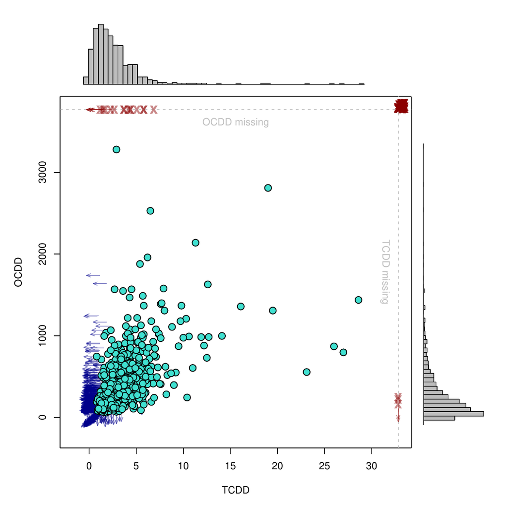

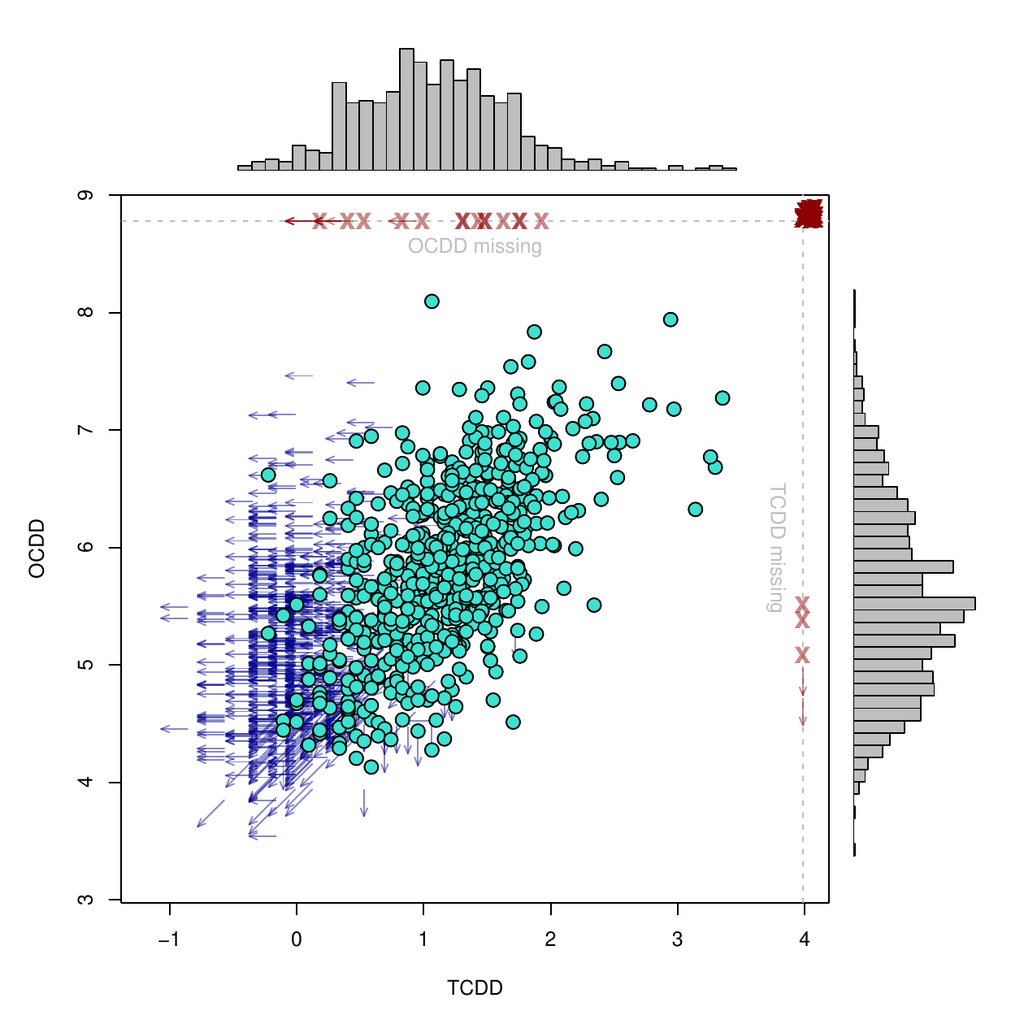

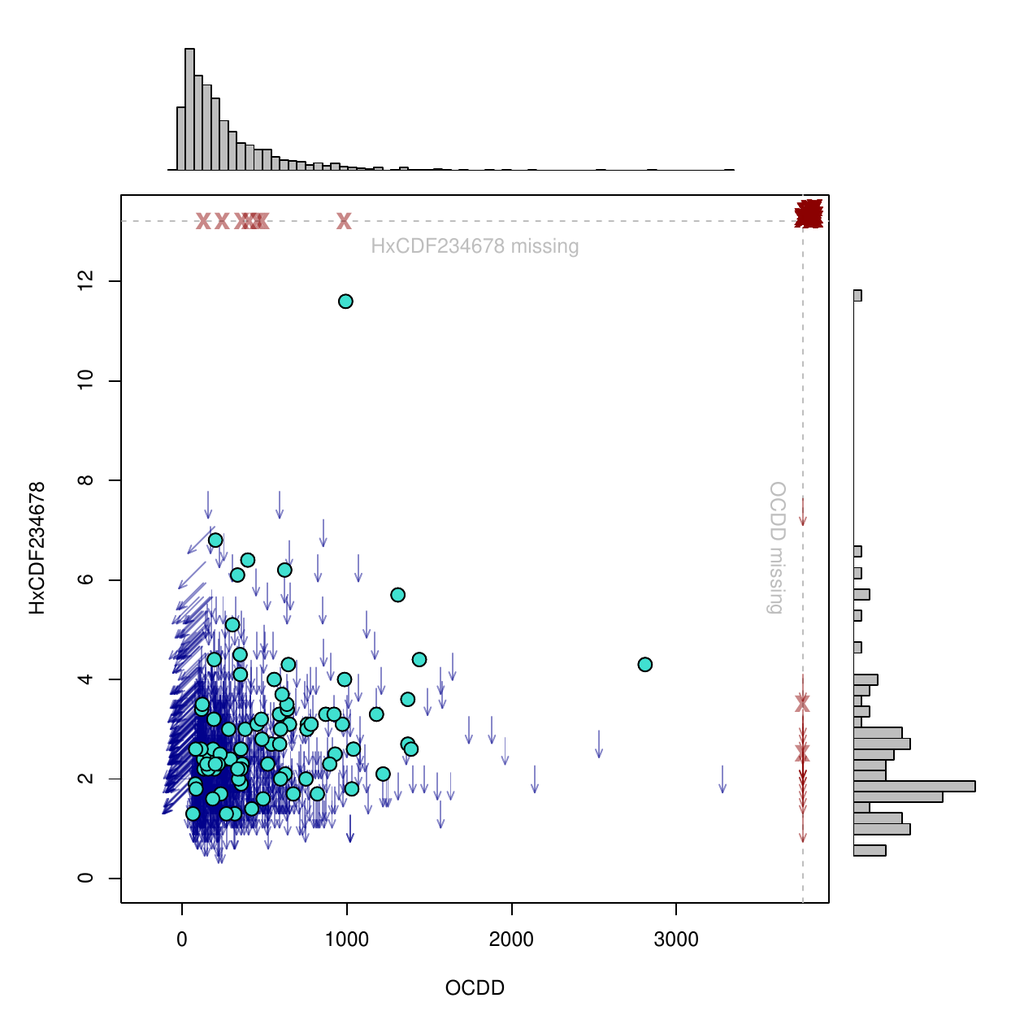

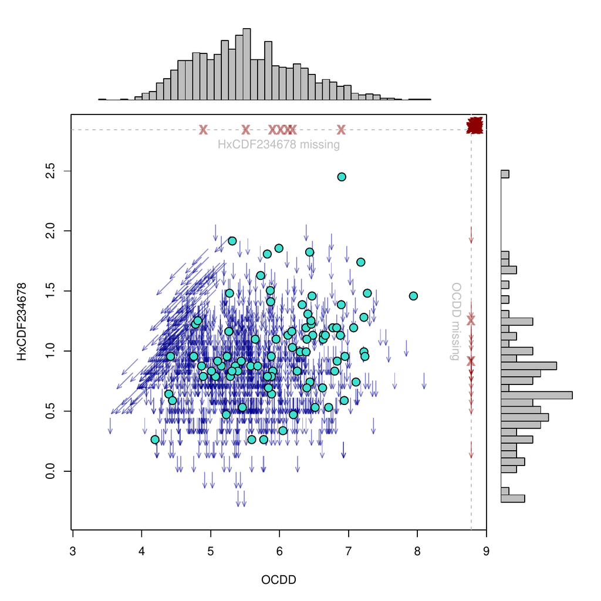

Figure 5: Example scatter plots between compound pairs with and without log transformation. Between *TCDD*(d1) and *ODD*(d7): (a) d1-d7 without log transformation, *ρ̂* = 0.22, *p* ≈ 0; (b) d1-d7 with log transformation, *ρ̂* = 0.60, *p* ≈ 0. Between *OCDD*(d7) and *HxCDF234678*(f6): (c) d7-f6 without log transformation, *ρ̂* = − 0.05, *p* ≈ 1; (d) d7-f6 with log transformation, *ρ̂* = 0.38, *p* ≈ 0. The histograms on top and right of each plot are marginal sample distributions from observed data.

Table 4: 95% confidence interval coverage probabilities for bivariate normal data with fixed point censoring. Coverage probabilities are estimated from 500 replications. The Binomial random error is about $\pm$0.01. Coverage probabilities in parentheses are calculated from Fisher transformation in the case of no censors. Data generated from the standard normal distribution with left censoring at $25\%$ and $75\%$ percentiles.

| Sample size | 0% Censoring rate |  |  | 25% Censoring rate |  |  | 75% Censoring rate |  |  |
| --- | --- | --- | --- | --- | --- | --- | --- | --- | --- |
|  | $\rho=0.00$ | $\rho=0.50$ | $\rho=0.95$ | $\rho=0.00$ | $\rho=0.50$ | $\rho=0.95$ | $\rho=0.00$ | $\rho=0.50$ | $\rho=0.95$ |
| n=50 | 0.938 | 0.962 | 0.946 | 0.938 | 0.946 | 0.968 | 0.958 | 0.954 | 0.956 |
|  | (0.956) | (0.968) | (0.954) | – | – | – | – | – | – |
| n=200 | 0.944 | 0.948 | 0.942 | 0.954 | 0.960 | 0.948 | 0.972 | 0.964 | 0.960 |
|  | (0.948) | (0.954) | (0.950) | – | – | – | – | – | – |
| n=500 | 0.932 | 0.934 | 0.952 | 0.946 | 0.948 | 0.964 | 0.952 | 0.944 | 0.964 |
|  | (0.938) | (0.948) | (0.954) | – | – | – | – | – | – |

Table 5: 95% confidence interval coverage probabilities for bivariate normal data with random censoring. Coverage probabilities are estimated from 500 replications. The Binomial random error is about $\pm$0.01. “–" means insufficient data for estimation.

| Sample size | Censoring distribution=N(-2,1) |  |  | Censoring distribution=N(0,1) |  |  | Censoring distribution=N(2,1) |  |  |
| --- | --- | --- | --- | --- | --- | --- | --- | --- | --- |
|  | Average censoring rate $\approx 0.25$ |  |  | Average censoring rate $\approx 0.50$ |  |  | Average censoring rate $\approx 0.75$ |  |  |
|  | $\rho=0.00$ | $\rho=0.50$ | $\rho=0.95$ | $\rho=0.00$ | $\rho=0.50$ | $\rho=0.95$ | $\rho=0.00$ | $\rho=0.50$ | $\rho=0.95$ |
| n=50 | 0.934 | 0.936 | 0.942 | 0.908 | 0.946 | 0.958 | – | – | – |
| n=200 | 0.958 | 0.968 | 0.948 | 0.942 | 0.962 | 0.958 | 0.942 | 0.946 | 0.930 |
| n=500 | 0.946 | 0.948 | 0.956 | 0.944 | 0.945 | 0.954 | 0.947 | 0.938 | 0.962 |

Table 6: Mean run time (sec.) for different settings of true correlations, sample sizes and censoring percentages. Mean time are estimated from 500 replications. Data are simulated from the standard bivariate normal distribution.

| Sample size | Censoring proportion configuration |  |  |  |  |  |  |  |  |
| --- | --- | --- | --- | --- | --- | --- | --- | --- | --- |
|  | (X 0%; XY 30%; Y 0%) |  |  | (X 15%; XY 15%; Y 15%) |  |  | (X 30%; XY 0%; Y 30%) |  |  |
|  | $\rho=0.00$ | $\rho=0.50$ | $\rho=0.95$ | $\rho=0.00$ | $\rho=0.50$ | $\rho=0.95$ | $\rho=0.00$ | $\rho=0.50$ | $\rho=0.95$ |
| n=50 | 36 | 50 | 59 | 22 | 25 | 32 | 1.2 | 1.4 | 1.8 |
| n=200 | 166 | 206 | 233 | 89 | 103 | 110 | 1.5 | 2.1 | 2.2 |
| n=500 | 267 | 515 | 728 | 176 | 275 | 374 | 1.8 | 2.4 | 3.5 |

Table 7: Bias (mean squared error) for bivariate normal data. Bias and MSE are estimated from 50 replications. “–" means insufficient data for estimation.

| Sample size | Censoring distribution=N(-2,1) |  |  | Censoring distribution=N(0,1) |  |  | Censoring distribution=N(2,1) |  |  |
| --- | --- | --- | --- | --- | --- | --- | --- | --- | --- |
|  | Average censoring rate $\approx 0.25$ |  |  | Average censoring rate $\approx 0.50$ |  |  | Average censoring rate $\approx 0.75$ |  |  |
|  | $\rho=0.00$ | $\rho=0.50$ | $\rho=0.95$ | $\rho=0.00$ | $\rho=0.50$ | $\rho=0.95$ | $\rho=0.00$ | $\rho=0.50$ | $\rho=0.95$ |
| n=50 | 0.006 | -0.021 | -0.018 | 0.031 | 0.007 | 0.008 | – | – | – |
|  | (0.019) | (0.030) | (0.053) | (0.035) | (0.064) | (0.076) | (–) | (–) | (–) |
| n=200 | -0.005 | -0.005 | -0.026 | 0.020 | 0.003 | -0.037 | -0.017 | 0.053 | 0.021 |
|  | (0.008) | (0.012) | (0.014) | (0.012) | (0.010) | (0.014) | (0.024) | (0.034) | (0.029) |
| n=500 | 0.005 | -0.008 | -0.002 | 0.008 | -0.001 | -0.010 | -0.006 | -0.018 | -0.010 |
|  | (0.002) | (0.003) | (0.005) | (0.003) | (0.006) | (0.007) | (0.010) | (0.009) | (0.013) |

Table 8: 95% confidence interval coverage probabilities on bivariate t generated data. Coverage probabilities are estimated from 500 replications. The Binomial random error is about $\pm$0.01. For each df setting, the coverage probabilities on the first line are from inference based on the bivariate Normal distribution and the coverage probabilities in parenthesis on the second line are from inference based on the bivariate $t-$distribution. The latter are only given when the coverage probability from using the bivariate normal is $\leq 0.91$.

| Degree of freedom | Sample size $=50$ |  |  | Sample size $=200$ |  |  | Sample size $=500$ |  |  |
| --- | --- | --- | --- | --- | --- | --- | --- | --- | --- |
|  | $\rho=0.00$ | $\rho=0.50$ | $\rho=0.95$ | $\rho=0.00$ | $\rho=0.50$ | $\rho=0.95$ | $\rho=0.00$ | $\rho=0.50$ | $\rho=0.95$ |
| df=3 | 0.95 | 0.81 | 0.69 | 0.96 | 0.76 | 0.55 | 0.96 | 0.70 | 0.54 |
|  |  | (0.93) | (0.93) |  | (0.97) | (0.97) |  | (0.95) | (0.96) |
| df=5 | 0.95 | 0.91 | 0.86 | 0.94 | 0.86 | 0.81 | 0.96 | 0.88 | 0.76 |
|  |  | (0.97) | (0.95) |  | (0.96) | (0.95) |  | (0.97) | (0.95) |
| df=10 | 0.94 | 0.93 | 0.89 | 0.93 | 0.96 | 0.89 | 0.95 | 0.94 | 0.91 |
|  |  |  | (0.93) |  |  | (0.94) |  |  | (0.94) |
| df=20 | 0.95 | 0.92 | 0.93 | 0.94 | 0.94 | 0.92 | 0.96 | 0.94 | 0.94 |

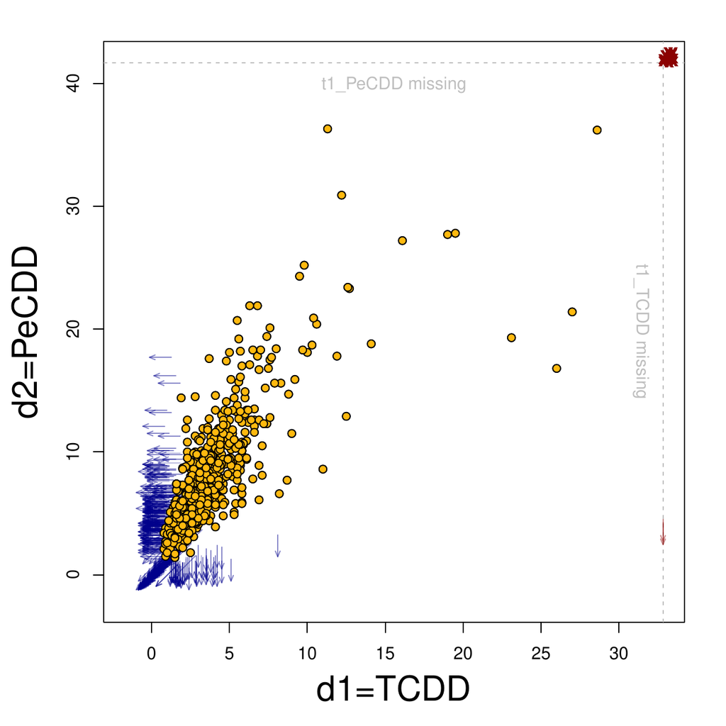

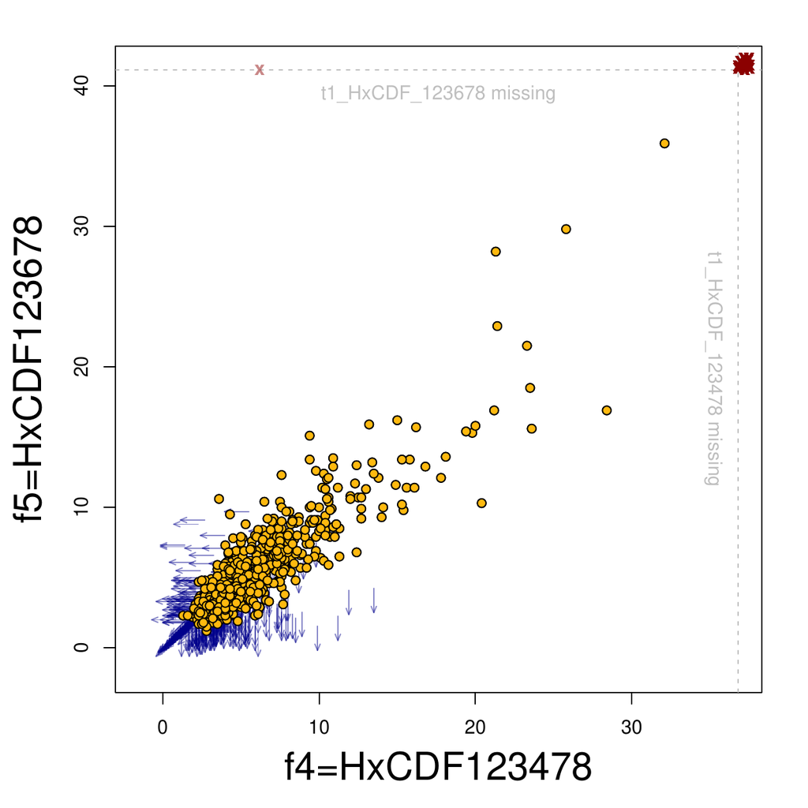

```r
R> splot2(NHANESD, "t1_TCDD", "t2_TCDD", "t1_PeCDD", "t2_PeCDD", xlab="d1=TCDD",
   + ylab="d2=PeCDD", bg="#FFB90F", cex.lab=2.0)

R> splot2(NHANESD, "t1_HxCDF_123478", "t2_HxCDF_123478", "t1_HxCDF_123678",
   + "t2_HxCDF_123678", xlab="f4=HxCDF123478", ylab="f5=HxCDF123678", bg="#FFB90F",
   + cex.lab=2.0)

R> splot2(NHANESD, "t1_PCB_156", "t2_PCB_156", "t1_PCB_157", "t2_PCB_157",
   + xlab="p3=PCB156", ylab="p4=PCB157", bg="#FFB90F", cex.lab=2.0)

R> splot2(NHANESD, "t1_PCB_105", "t2_PCB_105", "t1_PCB_118", "t2_PCB_118",
   + xlab="p1=PCB105", ylab="p2=PCB106", bg="#FFB90F", cex.lab=2.0).
```

1. d1 vs. d2: *ρ̂*<sub>*c**l**i**k**c**o**r**r*</sub> = 0.81, *ρ̂*<sub>*c**o**m**p**l**e**t**e*</sub> = 0.77, *n*<sub>*c**o**m**p**l**e**t**e*</sub> = 585
2. f4 vs. f5: *ρ̂*<sub>*c**l**i**k**c**o**r**r*</sub> = 0.85, *ρ̂*<sub>*c**o**m**p**l**e**t**e*</sub> = 0.89, *n*<sub>*c**o**m**p**l**e**t**e*</sub> = 717

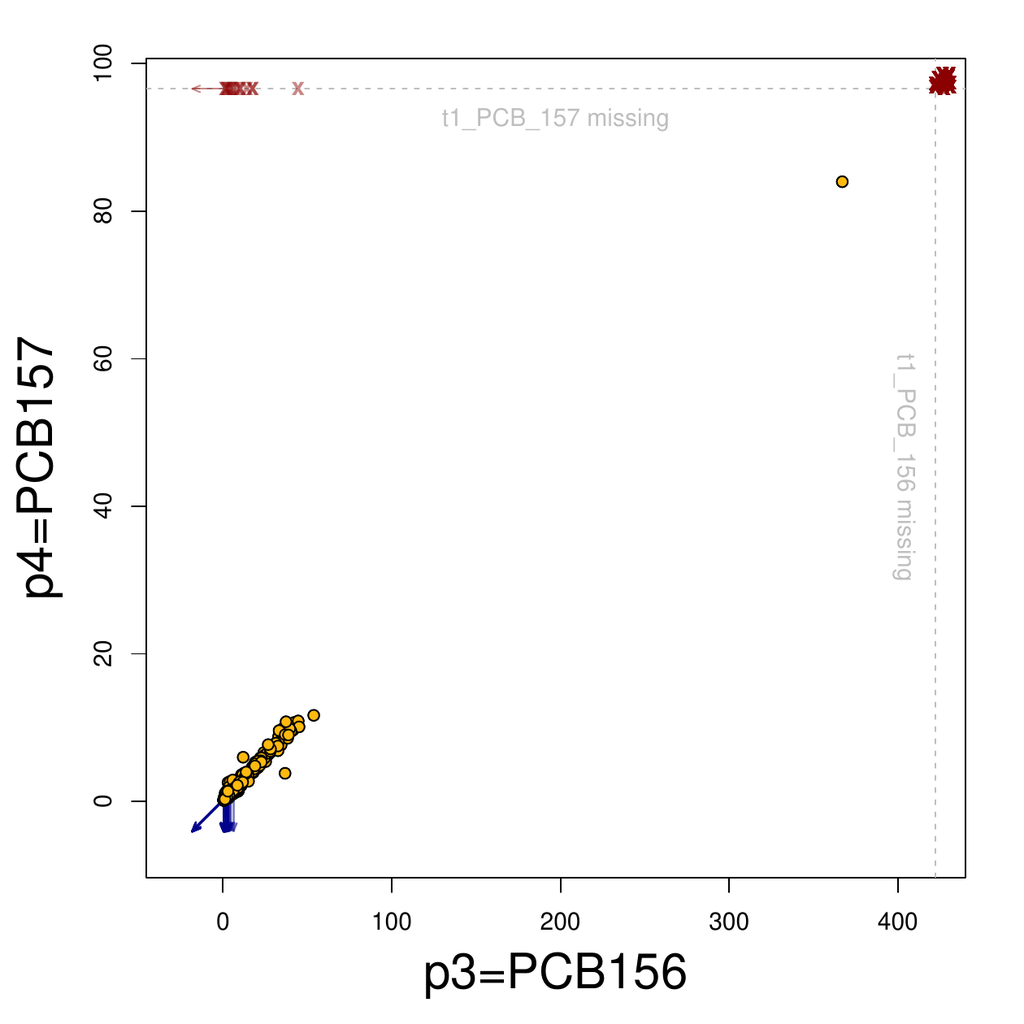

[figure not shown]

3. p3 vs. p4: *ρ̂*<sub>*c**l**i**k**c**o**r**r*</sub> = 0.99, *ρ̂*<sub>*c**o**m**p**l**e**t**e*</sub> = 0.99, *n*<sub>*c**o**m**p**l**e**t**e*</sub> = 1048
4. p1 vs. p2: *ρ̂* = 0.97, *ρ̂*<sub>*c**o**m**p**l**e**t**e*</sub> = 0.97, *n*<sub>*c**o**m**p**l**e**t**e*</sub> = 1340

Figure 6: Scatter plots of the most highly correlated chemical pairs in each of the dioxin, furan and PCB groups in the NHANES data.

Table 9: Correlation matrix for the NHANES dioxin data using *clikcorr*, upper-right=raw data, lower-left=log-transformed data.

|  | Chemical index |  |  |  |  |  |  |  |  |  |  |  |  |  |  |  |  |  |  |  |  |  |
| --- | --- | --- | --- | --- | --- | --- | --- | --- | --- | --- | --- | --- | --- | --- | --- | --- | --- | --- | --- | --- | --- | --- |
|  | d1 | d2 | d3 | d4 | d5 | d6 | d7 | f1 | f2 | f3 | f4 | f5 | f6 | f7 | f8 | f9 | p1 | p2 | p3 | p4 | p5 | p6 |
| d1 | – | **.81** | .68 | .67 | .61 | .50 | .22 | .22 | .30 | .66 | .65 | .62 | .36 | .08 | .05 | .01 | .44 | .47 | .30 | .39 | .57 | .36 |
|  | – | $0$ | $0$ | $0$ | $0$ | $0$ | $0$ | $0$ | $1$ | $0$ | $0$ | $0$ | $0$ | (.01) | (.46) | (.82) | $0$ | $0$ | $0$ | $0$ | $0$ | $0$ |
| d2 | .79 | – | .78 | **.80** | .70 | .52 | .56 | .46 | .29 | .73 | .71 | .71 | .40 | .10 | .08 | .03 | .42 | .47 | .36 | .49 | .61 | .38 |
|  | (0) | – | $0$ | $0$ | $0$ | $0$ | $0$ | $0$ | (.01) | $0$ | $0$ | $0$ | $0$ | $0$ | (.17) | (.45) | $0$ | $0$ | $0$ | $0$ | $0$ | $0$ |
| d3 | .69 | .79 | – | .71 | .75 | .58 | .50 | .19 | .19 | .60 | .62 | .61 | .41 | .07 | .13 | .08 | .32 | .35 | .32 | .36 | .49 | .39 |
|  | (0) | (0) | – | $0$ | $0$ | $0$ | $1$ | $0$ | (.02) | $0$ | $0$ | $0$ | $0$ | (.01) | (.18) | $1$ | $0$ | $0$ | $0$ | $0$ | $0$ | $0$ |
| d4 | .65 | .73 | **.83** | – | .66 | .58 | .69 | .15 | .13 | .75 | .79 | .77 | .36 | .13 | .05 | .00 | .40 | .46 | .46 | .51 | .60 | .39 |
|  | (0) | (0) | (0) | – | $0$ | $0$ | $0$ | (.01) | $1$ | $0$ | $0$ | $0$ | $0$ | $0$ | $1$ | $1$ | $0$ | $0$ | $0$ | $0$ | $0$ | $0$ |
| d5 | .60 | .66 | .75 | .74 | – | .55 | .73 | .30 | .50 | .56 | .60 | .63 | .47 | .13 | .42 | .18 | .32 | .34 | .24 | .28 | .42 | .27 |
|  | (0) | (0) | (0) | (0) | – | $0$ | $0$ | $0$ | $1$ | $0$ | $0$ | $0$ | $0$ | $0$ | $1$ | $1$ | $0$ | $0$ | $0$ | $0$ | $0$ | $0$ |
| d6 | .54 | .49 | .65 | .56 | .59 | – | .76 | .14 | .15 | .45 | .57 | .51 | .31 | .15 | .12 | .06 | .39 | .41 | .22 | .26 | .41 | .21 |
|  | (0) | (0) | (0) | (0) | (0) | – | $0$ | (.08) | $1$ | $0$ | $0$ | $0$ | $0$ | $0$ | $1$ | $1$ | $0$ | $0$ | $0$ | $0$ | $0$ | $0$ |
| d7 | .60 | .58 | .69 | .66 | .65 | .77 | – | .19 | .33 | .59 | .70 | .60 | -.05 | .14 | -.53 | .03 | .38 | .41 | .28 | .36 | .56 | .25 |
|  | (0) | (0) | (0) | (0) | (0) | (0) | – | (.01) | $1$ | $0$ | $0$ | $0$ | $1$ | $0$ | $1$ | (.61) | $0$ | $0$ | $0$ | $0$ | $0$ | $0$ |
| f1 | .29 | .45 | .20 | .23 | .35 | .19 | .24 | – | **.83** | .37 | .33 | .36 | .76 | -.04 | -.27 | .24 | .15 | .15 | .09 | .10 | .19 | .61 |
|  | (0) | (0) | (0) | (0) | (0) | (0) | (0) | – | $0$ | $0$ | $0$ | $0$ | $0$ | (.39) | $1$ | $1$ | $0$ | $0$ | (.34) | (.05) | $0$ | $1$ |
| f2 | .22 | .20 | .16 | -.01 | .21 | .17 | .20 | .76 | – | .46 | .36 | .43 | **.82** | .06 | .46 | .21 | .09 | .08 | .05 | .07 | .11 | .57 |
|  | (0) | (0) | (.05) | (1) | (.02) | (.04) | (.02) | (0) | – | $0$ | $0$ | $0$ | $0$ | (.50) | (.04) | $1$ | (.12) | (.16) | (.44) | (.19) | (.09) | $1$ |
| f3 | .67 | .69 | .70 | .74 | .62 | .47 | .59 | .52 | .55 | – | .78 | **.81** | .53 | .12 | .05 | .02 | .49 | .54 | .45 | .51 | .65 | .38 |
|  | (0) | (0) | (0) | (0) | (0) | (0) | (0) | (0) | (0) | – | $0$ | $0$ | $0$ | $0$ | (.48) | $1$ | $0$ | $0$ | $0$ | $0$ | $0$ | $0$ |
| f4 | .63 | .62 | .67 | .74 | .61 | .57 | .67 | .34 | .41 | .73 | – | **.85** | .50 | .18 | -.07 | .03 | .44 | .48 | .34 | .41 | .56 | .31 |
|  | (0) | (0) | (0) | (0) | (0) | (0) | (0) | (0) | (0) | (0) | – | $0$ | $0$ | $0$ | (.30) | $1$ | $0$ | $0$ | $0$ | $0$ | $0$ | $0$ |
| f5 | .62 | .67 | .66 | .75 | .65 | .55 | .62 | .42 | .49 | .77 | .79 | – | .58 | .18 | .001 | .14 | .38 | .42 | .34 | .40 | .51 | .29 |
|  | (0) | (0) | (0) | (0) | (0) | (0) | (0) | (0) | (0) | (0) | (0) | – | $0$ | $0$ | (.99) | $1$ | $0$ | $0$ | $0$ | $0$ | $0$ | $0$ |
| f6 | .39 | .42 | .43 | .52 | .53 | .48 | .38 | .53 | .78 | .62 | .59 | .67 | – | .12 | .23 | .36 | .19 | .33 | .11 | .13 | .23 | .26 |
|  | (0) | (0) | (0) | (0) | (0) | (0) | (0) | (0) | (0) | (0) | (0) | (0) | – | $0$ | (.02) | $1$ | $0$ | $1$ | $0$ | $0$ | $0$ | $0$ |
| f7 | .18 | .20 | .27 | .30 | .34 | .28 | .31 | .21 | .19 | .26 | .39 | .42 | .38 | – | 0 | .13 | .06 | .06 | .05 | .05 | .06 | .04 |
|  | (0) | (0) | (0) | (0) | (0) | (0) | (0) | (0) | (.01) | (0) | (0) | (0) | (0) | – | $1$ | (.13) | (.03) | (.02) | (.06) | (.05) | (.05) | (.25) |
| f8 | .08 | .12 | .14 | .02 | .31 | .06 | .03 | .31 | .32 | .08 | -.02 | .05 | .29 | .13 | – | .28 | .01 | .02 | .02 | -.05 | .06 | -.15 |
|  | (.19) | (.06) | (.03) | (.75) | (0) | (.27) | (.54) | (0) | (0) | (.18) | (.77) | (.44) | (0) | (.02) | – | $0$ | (.91) | $1$ | $1$ | (.40) | $1$ | (.05) |
| f9 | .02 | .03 | .04 | .01 | .08 | .01 | .05 | .08 | .11 | .06 | .07 | .08 | .09 | .20 | .42 | – | .05 | .01 | .06 | .09 | .05 | .02 |
|  | (.56) | (.47) | (.37) | (.84) | (.05) | (.85) | (.17) | (.30) | (.32) | (.11) | (.05) | (.03) | (.19) | (0) | (0) | – | $1$ | (.55) | $1$ | $1$ | (.61) | $1$ |
| p1 | .58 | .53 | .53 | .50 | .48 | .51 | .54 | .31 | .36 | .59 | .54 | .51 | .34 | .15 | .02 | .08 | – | **.97** | .42 | .44 | .67 | .27 |
|  | (0) | (0) | (0) | (0) | (0) | (0) | (0) | (0) | (1) | (0) | (0) | (0) | (0) | (0) | (.68) | (.03) | – | $0$ | $0$ | $0$ | $0$ | $0$ |
| p2 | .64 | .59 | .58 | .60 | .52 | .56 | .62 | .32 | .17 | .67 | .61 | .57 | .35 | .15 | .01 | .08 | **.96** | – | .52 | .54 | .79 | .31 |
|  | (0) | (0) | (0) | (0) | (0) | (0) | (0) | (0) | (.02) | (0) | (0) | (0) | (0) | (0) | (.85) | (.02) | (0) | – | $0$ | $0$ | $0$ | $0$ |
| p3 | .64 | .68 | .72 | .69 | .53 | .39 | .55 | .32 | .21 | .73 | .63 | .64 | .48 | .13 | -.05 | .05 | .60 | .71 | – | **.99** | **.83** | .69 |
|  | (0) | (0) | (0) | (0) | (0) | (0) | (0) | (0) | (.02) | (0) | (0) | (0) | (0) | (0) | (.39) | (.15) | (0) | (0) | – | $0$ | $0$ | $0$ |
| p4 | .65 | .67 | .67 | .68 | .47 | .38 | .55 | .30 | .26 | .71 | .62 | .60 | .35 | .12 | -.08 | .02 | .63 | .72 | **.96** | – | **.88** | .72 |
|  | (0) | (0) | (0) | (0) | (0) | (0) | (0) | (0) | (0) | (0) | (0) | (0) | (0) | (0) | (.16) | (.64) | (0) | (0) | (0) | – | $0$ | $0$ |
| p5 | .63 | .65 | .67 | .65 | .48 | .48 | .59 | .44 | .22 | .69 | .62 | .59 | .31 | .10 | -.06 | .03 | .75 | .83 | **.89** | **.88** | – | .56 |
|  | (0) | (0) | (0) | (0) | (0) | (0) | (0) | (0) | (.05) | (0) | (0) | (0) | (0) | (0) | (.35) | (.40) | (0) | (0) | (0) | (0) | – | $0$ |
| p6 | .39 | .39 | .41 | .43 | .29 | .23 | .30 | .23 | .17 | .44 | .33 | .33 | .29 | .11 | -.17 | -.07 | .35 | .41 | .62 | .67 | .59 | – |
|  | (0) | (0) | (0) | (0) | (0) | (0) | (0) | (0) | (.15) | (0) | (0) | (0) | (0) | (0) | (.02) | (.10) | (0) | (0) | (0) | (0) | (0) | – |

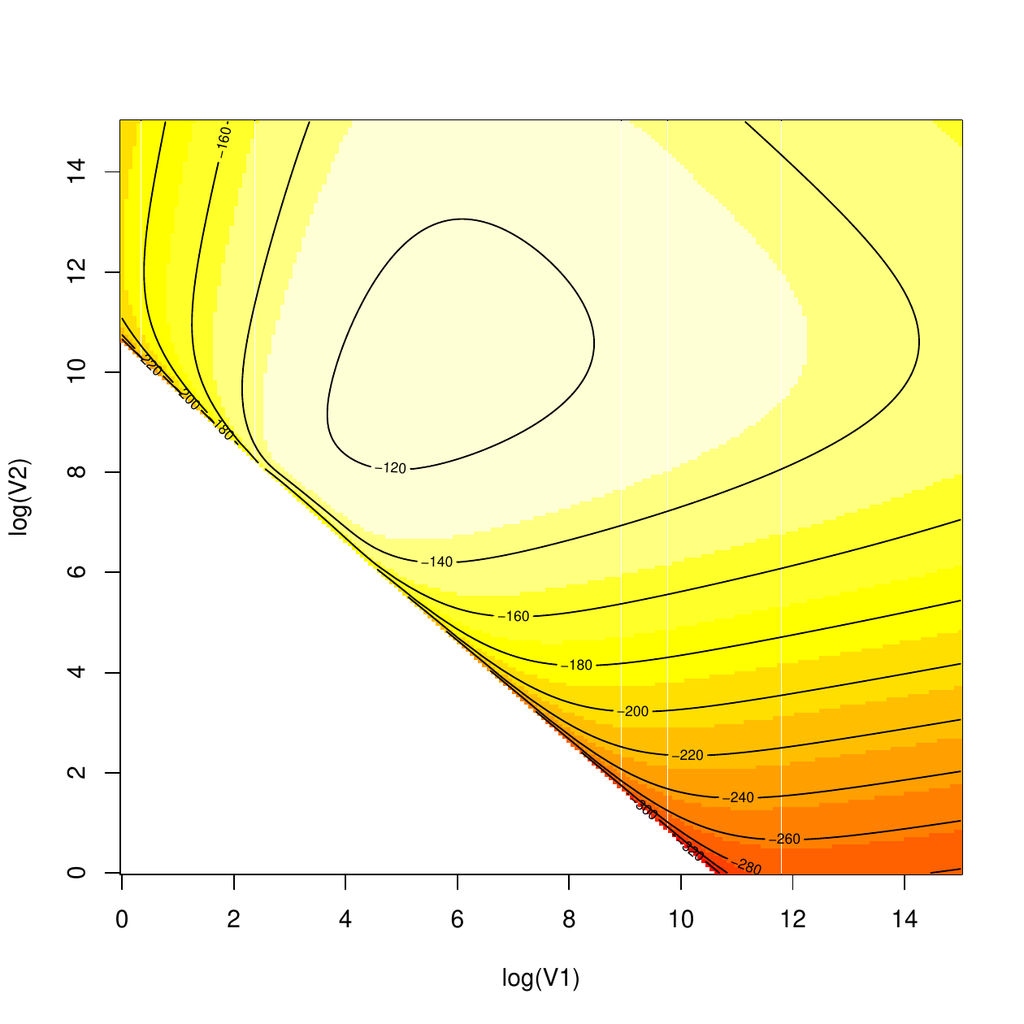

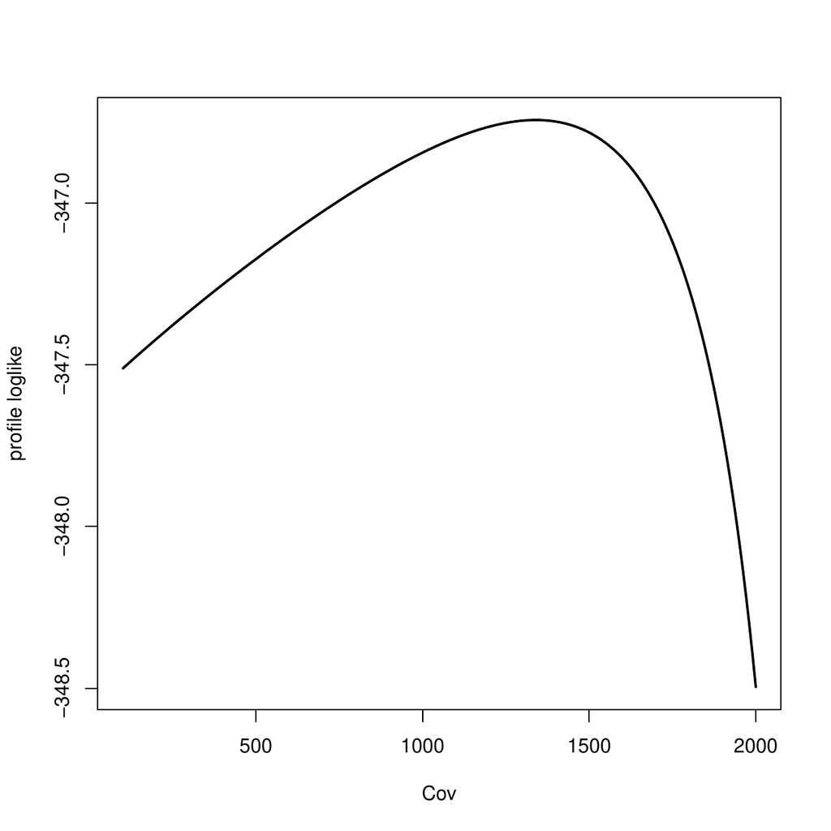

Figure 7: Illustration of effects of starting values on parameter estimates from profile log likelihood surfaces or curves. Upper panel: the profile joint log likelihood of parameters (log(*σ*<sub>*X*</sub><sup>2</sup>),log(*σ*<sub>*Y*</sub><sup>2</sup>)) with the mean and correlation parameters set at certain starting values. Values from highest to lowest are colored in order of white, yellow and red; Lower panel: the profile likelihood of covariance parameter with mean and variance parameters fixed at certain starting values.

Allison, Paul David. 2010. *Survival Analysis Using SAS: A Practical Guide*. NC USA: SAS Institute Inc.

Bryson, Maurice C. 1974. “Heavy-Tailed Distributions: Properties and Tests.” *Technometrics* 16: 61–68. http://dx.doi.org/10.1080/00401706.1974.10489150.

Fisher, R. A. 1915. “Frequency Distribution of the Values of the Correlation Coefficient in Samples of an Indefinitely Large Population.” *Biometrika* 10 (4): 507–21. http://dx.doi.org/10.2307/2331838.

Genz, Alan, and Frank Bretz. 2009. *Computation of Multivariate Normal and $t$ Probabilities*. Lecture Notes in Statistics. Heideberg: Springer-Verlag.

Genz, Alan, Frank Bretz, Tetsuhisa Miwa, Xuefei Mi, Friedrich Leisch, Fabian Scheipl, and Torsten Hothorn. 2012. *mvtnorm: Multivariate Normal and t Distributions*. http://CRAN.R-project.org/package=mvtnorm.

Giolo, Suely Ruiz. 2004. “Turnbull’s Nonparametric Estimator for Interval-Censored Data.” *Technical Report*. http://www.est.ufpr.br/rt/suely04a.pdf.

Helsel, Dennis R. 2005. *Nondetects and Data Analysis: Statistics for Censored Environmental Data*. New Jersey: John Wiley & Sons.

———. 2012. *Statistics for Censored Environmental Data Using MINITAB and R*. New Jersey: John Wiley & Sons.

Hothorn, Torsten, Frank Bretz, and Alen Genz. 2013. *On Multivariate t and Gauss Probabilities in r*. http://cran.r-project.org/web/packages/mvtnorm/vignettes/MVT_Rnews.pdf.

Jaspers, Veerle L., Dorte Herzke, Igor Eulaers, Brenda W. Gillespie, and Marcel Eens. 2013. “Perfluoroalkyl Substances in Soft Tissues and Tail Feathers of Belgian Barn Owls Using Statistical Methods for Left Censored Data to Handle Non-Detects.” *Environment International* 52: 9–16. https://doi.org/10.1016/j.envint.2012.11.002.

Li, Liang, William Wang, and Ivan Chan. 2005. “Correlation Coefficient Inference on Censored Bioassay Data.” *Journal of Biopharmaceutical Statistics* 15 (3): 501–12. https://doi.org/10.1081/BIP-200056552.

Li, Y., K. Shedden, B. W. Gillespie, and J. A. Gillespie. 2016. *clikcorr: Censoring Data and Likelihood-Based Correlation Estimation*. https://cran.r-project.org/web/packages/clikcorr/.

Little, Roderick J. A., and Donald B. Rubin. 2002. *Statistical Analysis with Missing Data*. New York: John Wiley & Sons.

Murphy, S. A., and A. W. van der Vaart. 2000. “On Profile Likelihood.” *J. Amer. Statist. Assoc* 95: 449–65. [https://doi.org/10.1080/01621459.2000.10474219{"}](https://doi.org/10.1080/01621459.2000.10474219%7B%22%7D).

R Core Team. 2013a. *General-Purpose Optimization. The r Stats Package*. http://stat.ethz.ch/R-manual/R-devel/library/stats/html/optim.html.

———. 2013b. *Non-Linear Minimization. The r Stats Package*. http://ugrad.stat.ubc.ca/R/library/stats/html/nlm.html.

Rao, C. R. 1973. *Linear Statistical Inference and Its Applications*. New York: John Wiley & Sons.

Resnick, Sidney I. 2007. *Heavy-Tail Phenomena Probabilistic and Statistical Modeling*. New York: Springer-Verlag.

Schemper, M., A. Kaider, S. Wakounig, and G. Heinze. 2013. “Estimating the Correlation of Bivariate Failure Times Under Censoring.” *Stat Med.* 32 (27): 4781–90. https://doi.org/10.1002/sim.5874.

Stryhn, H., and J. Christensen. 2003. “Confidence Intervals by the Profile Likelihood Methods, with Applications in Veterinary Epidemiology.” *Proceedings of the 10th International Symposium on Veterinary Epidemiology and Economics*, 208–11.

Therneau, Terry M. 2015. *A Package for Survival Analysis in s*. https://CRAN.R-project.org/package=survival.

Venzon, D. J., and S. H. Moolgavkar. 1988. “A Method for Computing Profile-Likelihood-Based Confidence Intervals.” *Appl. Statist.* 37 (1): 87. https://doi.org/10.2307/2347496.

Zhou, H., Z. Liao, S. Liu, W. Liang, X. Zhang, and C. Ou. 2012. “Comparison of Three Methods in Estimating Confidence Interval and Hypothesis Testing of Logistic Regression Coefficients.” *Journal of Mathematical Medicine* 25 (4): 393–95.